# Bellabeat_rmd

Lee CLark

2025-11-23

# Usage Trends in FitBit Data for Bellabeat Capstone Project

## Packages

tidyverse, here, skimr, janitor, lubridate.

## Business Task

To analyze smart device usage data to gain insight into how non-Bellabeat devices are used. Choose one product to apply these insights to. What are some trends in smart device usage? How could these trends apply to Bellabeat customer? How could these trends influence Bellabeat marketing strategy?

## Data Sources

[FitBit Fitness Tracker Data](https://www.kaggle.com/datasets/arashnic/fitbit) (CC0: Public Domain, data set made available through [Mobius](https://www.kaggle.com/arashnic)): This Kaggle data set contains personal fitness tracker from thirty FitBit users. Thirty eligible Fitbit users consented to the submission of personal tracker data, including minute-level output for physical activity, heart rate, and sleep monitoring. It includes information about daily activity, steps, and heart rate that can be used to explore users’ habits.  
It should be noted that the Calories in the below analysis are dietary Calories or kilocalories (kcal).

## Data Cleaning

Duplicated tables for cleaning and converted all column names to snake case.

Converted all dates and times from character into correct date or date/time format.

Found 543 duplicates in minute_sleep. Found 3 duplicates in sleep_day. sum(duplicated(date_frame_name)) Removed duplicates.

Many tables have 33 unique ids. However, some have fewer. Notables are: heartrate_seconds at 14, minute_sleep at 24, sleep_day at 24, and weight_log_info at 8.

Checked for missing values (NA). There were 65 missing values in weight_log_info.

The missing values are all in the fat column, data in the other columns may prove useful so rows were not deleted.

## Summary Statistics

```
## daily_activity
```

|  | total_steps | total_distance | sedentary_minutes |
| --- | --- | --- | --- |
|  | Min. : 0 | Min. : 0.000 | Min. : 0.0 |
|  | 1st Qu.: 3790 | 1st Qu.: 2.620 | 1st Qu.: 729.8 |
|  | Median : 7406 | Median : 5.245 | Median :1057.5 |
|  | Mean : 7638 | Mean : 5.490 | Mean : 991.2 |
|  | 3rd Qu.:10727 | 3rd Qu.: 7.713 | 3rd Qu.:1229.5 |
|  | Max. :36019 | Max. :28.030 | Max. :1440.0 |

```
## sleep_day
```

|  | total_sleep_records | total_minutes_asleep | total_time_in_bed |
| --- | --- | --- | --- |
|  | Min. :1.00 | Min. : 58.0 | Min. : 61.0 |
|  | 1st Qu.:1.00 | 1st Qu.:361.0 | 1st Qu.:403.8 |
|  | Median :1.00 | Median :432.5 | Median :463.0 |
|  | Mean :1.12 | Mean :419.2 | Mean :458.5 |
|  | 3rd Qu.:1.00 | 3rd Qu.:490.0 | 3rd Qu.:526.0 |
|  | Max. :3.00 | Max. :796.0 | Max. :961.0 |

Summarized statistics for the daily_intensities table.

```
## Summary of Activity Intensities
```

|  | sedentary_minutes | lightly_active_minutes | fairly_active_minutes | very_active_minutes |
| --- | --- | --- | --- | --- |
|  | Min. : 4869 | Min. : 412 | Min. : 6.0 | Min. : 3.0 |
|  | 1st Qu.:22296 | 1st Qu.:4438 | 1st Qu.: 110.0 | 1st Qu.: 111.0 |
|  | Median :26364 | Median :6144 | Median : 318.0 | Median : 287.0 |
|  | Mean :28234 | Mean :5492 | Mean : 386.4 | Mean : 602.9 |
|  | 3rd Qu.:34598 | 3rd Qu.:7276 | 3rd Qu.: 594.0 | 3rd Qu.: 726.0 |
|  | Max. :40840 | Max. :9548 | Max. :1838.0 | Max. :2640.0 |

# Plots

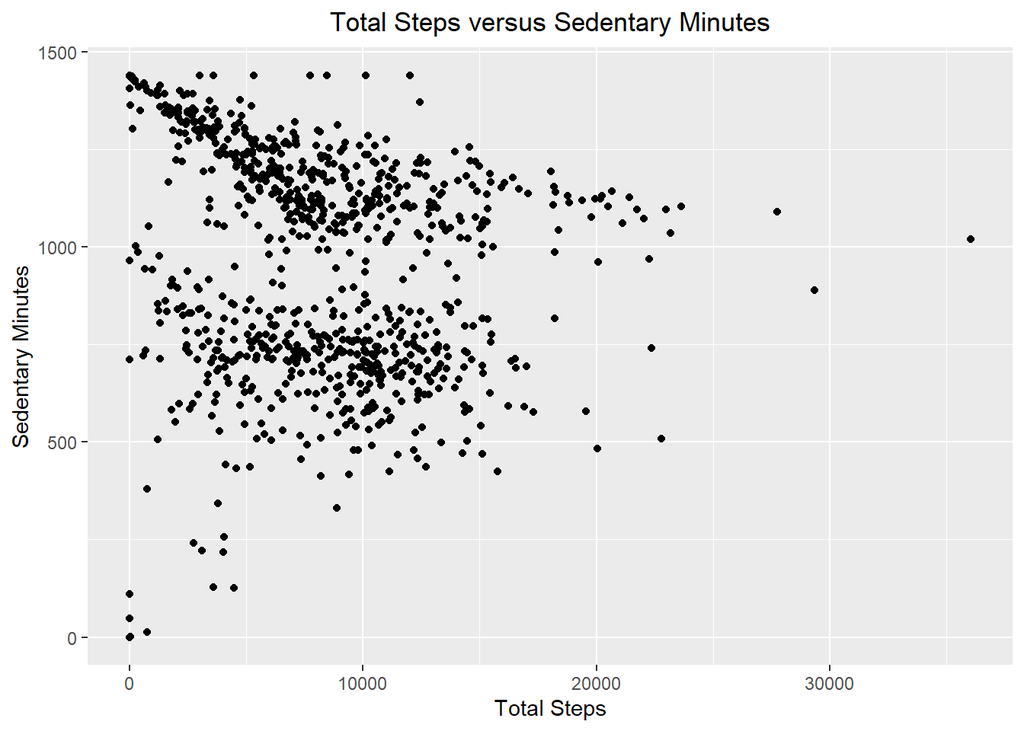

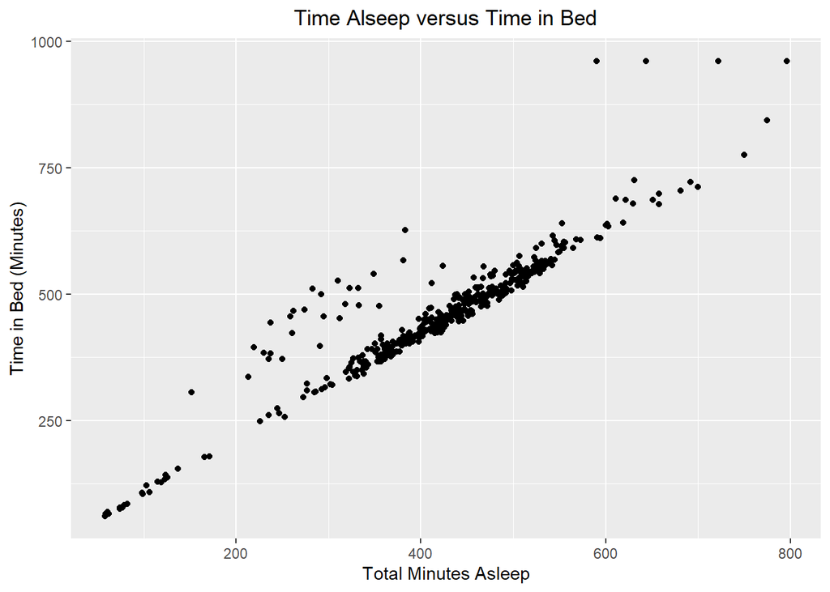

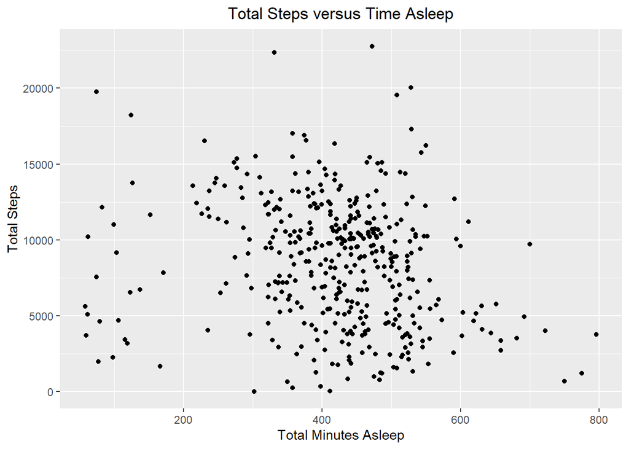

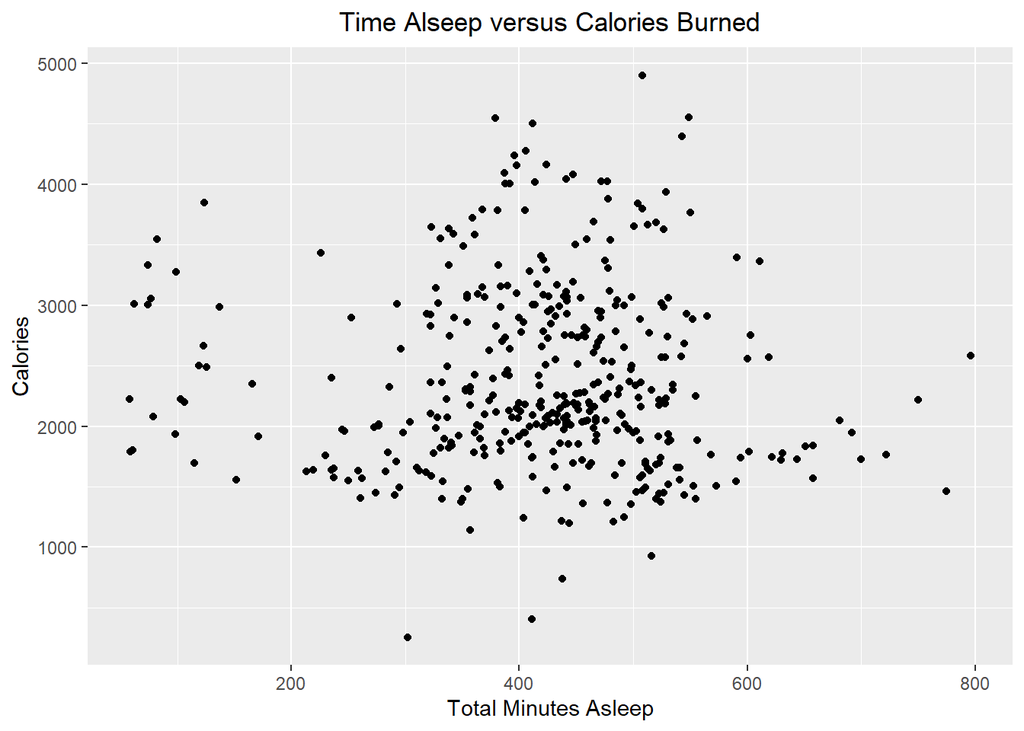

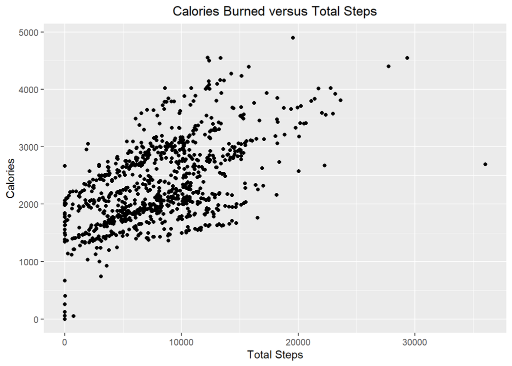

[figure not shown]

[figure not shown]

[figure not shown]

[figure not shown]

Condensed median minutes of activity into a table for plotting a bar graph.

Median time at each activity level over one month.

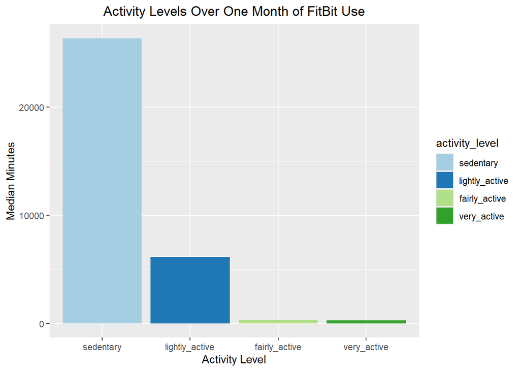

## Conclusion

These were the original questions: What are some trends in smart device usage? How could these trends apply to Bellabeat customer? How could these trends influence Bellabeat marketing strategy?